# Exploratory Analysis for Final Project

Deisy Diaz

5/4/2021

# Question

#### Does the type of gaming platform have an effect in the video game sales in specific regions? Is one platform more popular in a region compared to another?

```r
setwd("C:/Users/jd100/Desktop/UCR Classes/Spring 21/Stat 167/Final Project")
video_game_data <- read_csv("Video_Games_Sales.csv")
video_game_data <-
  video_game_data %>%
  filter(!is.na(Name), !is.na(Platform), !is.na(Year_of_Release), !is.na(Genre), !is.na(Publisher), !is.na(NA_Sales), !is.na(EU_Sales), !is.na(JP_Sales), !is.na(Other_Sales), !is.na(Global_Sales))

video_game_data$User_Score <-
  as.numeric(video_game_data$User_Score)
```

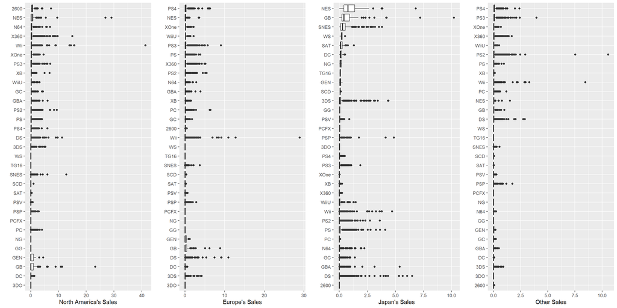

```r
plot1 <- ggplot(video_game_data, mapping = aes(x = reorder(Platform, NA_Sales, FUN = median), y = NA_Sales)) +
  geom_boxplot() +
  ylab("North America's Sales") +
  xlab("") +
  coord_flip()

plot2 <- ggplot(video_game_data, mapping = aes(x = reorder(Platform, EU_Sales, FUN = median), y = EU_Sales)) +
  geom_boxplot() +
  ylab("Europe's Sales") +
  xlab("") +
  coord_flip()

plot3 <- ggplot(video_game_data, mapping = aes(x = reorder(Platform, JP_Sales, FUN = median), y = JP_Sales)) +
  geom_boxplot() +
  ylab("Japan's Sales") +
  xlab("") +
  coord_flip()

plot4 <- ggplot(video_game_data, mapping = aes(x = reorder(Platform, Other_Sales, FUN = median), y = Other_Sales)) +
  geom_boxplot() +
  ylab("Other Sales") +
  xlab("") +
  coord_flip()

grid.arrange(plot1, plot2, plot3, plot4, ncol = 4)
```

From the plots above, we see that the 2600 gaming platform is number 1 in North America, where as it is number 14 in Europe, and number 31 in Japan and other. As for Europe’s number one platform, the PS4, it is number 14 in North America, number 17 in Japan, and number 1 in Other. Japan’s number 1 platform is NES, whereas it is number 2 in North America and Europe, and number 11 in other. For other sales, the PS4 is also the number 1 platform.

```r
grouped_video_game <-
  video_game_data %>%
  group_by(Platform)
grouped_video_game
```

```
## # A tibble: 16,717 x 16
## # Groups:   Platform [31]
##    Name  Platform Year_of_Release Genre Publisher NA_Sales EU_Sales JP_Sales
##    <chr> <chr>    <chr>           <chr> <chr>        <dbl>    <dbl>    <dbl>
##  1 Wii ~ Wii      2006            Spor~ Nintendo      41.4    29.0      3.77
##  2 Supe~ NES      1985            Plat~ Nintendo      29.1     3.58     6.81
##  3 Mari~ Wii      2008            Raci~ Nintendo      15.7    12.8      3.79
##  4 Wii ~ Wii      2009            Spor~ Nintendo      15.6    10.9      3.28
##  5 Poke~ GB       1996            Role~ Nintendo      11.3     8.89    10.2
##  6 Tetr~ GB       1989            Puzz~ Nintendo      23.2     2.26     4.22
##  7 New ~ DS       2006            Plat~ Nintendo      11.3     9.14     6.5
##  8 Wii ~ Wii      2006            Misc  Nintendo      14.0     9.18     2.93
##  9 New ~ Wii      2009            Plat~ Nintendo      14.4     6.94     4.7
## 10 Duck~ NES      1984            Shoo~ Nintendo      26.9     0.63     0.28
## # ... with 16,707 more rows, and 8 more variables: Other_Sales <dbl>,
## #   Global_Sales <dbl>, Critic_Score <dbl>, Critic_Count <dbl>,
## #   User_Score <dbl>, User_Count <dbl>, Developer <chr>, Rating <chr>
```

```r
grouped_video_game %>%
  count() %>%
  filter(n == 1)
```

```
## # A tibble: 2 x 2
## # Groups:   Platform [2]
##   Platform     n
##   <chr>    <int>
## 1 GG           1
## 2 PCFX         1
```

```r
grouped_video_game %>%
  filter(Platform == "GG"| Platform == "PCFX")
```

```
## # A tibble: 2 x 16
## # Groups:   Platform [2]
##   Name  Platform Year_of_Release Genre Publisher NA_Sales EU_Sales JP_Sales
##   <chr> <chr>    <chr>           <chr> <chr>        <dbl>    <dbl>    <dbl>
## 1 Soni~ GG       1992            Plat~ Sega             0        0     0.04
## 2 Blue~ PCFX     1996            Role~ NEC              0        0     0.03
## # ... with 8 more variables: Other_Sales <dbl>, Global_Sales <dbl>,
## #   Critic_Score <dbl>, Critic_Count <dbl>, User_Score <dbl>, User_Count <dbl>,
## #   Developer <chr>, Rating <chr>
```

```r
games_with_sales <- video_game_data %>%
  filter(NA_Sales > 0| EU_Sales > 0| JP_Sales > 0| Other_Sales > 0)

games_with_sales
```

```
## # A tibble: 16,715 x 16
##    Name  Platform Year_of_Release Genre Publisher NA_Sales EU_Sales JP_Sales
##    <chr> <chr>    <chr>           <chr> <chr>        <dbl>    <dbl>    <dbl>
##  1 Wii ~ Wii      2006            Spor~ Nintendo      41.4    29.0      3.77
##  2 Supe~ NES      1985            Plat~ Nintendo      29.1     3.58     6.81
##  3 Mari~ Wii      2008            Raci~ Nintendo      15.7    12.8      3.79
##  4 Wii ~ Wii      2009            Spor~ Nintendo      15.6    10.9      3.28
##  5 Poke~ GB       1996            Role~ Nintendo      11.3     8.89    10.2
##  6 Tetr~ GB       1989            Puzz~ Nintendo      23.2     2.26     4.22
##  7 New ~ DS       2006            Plat~ Nintendo      11.3     9.14     6.5
##  8 Wii ~ Wii      2006            Misc  Nintendo      14.0     9.18     2.93
##  9 New ~ Wii      2009            Plat~ Nintendo      14.4     6.94     4.7
## 10 Duck~ NES      1984            Shoo~ Nintendo      26.9     0.63     0.28
## # ... with 16,705 more rows, and 8 more variables: Other_Sales <dbl>,
## #   Global_Sales <dbl>, Critic_Score <dbl>, Critic_Count <dbl>,
## #   User_Score <dbl>, User_Count <dbl>, Developer <chr>, Rating <chr>
```

```r
mean_over_zero <- grouped_video_game %>%
  mutate(avg_NA_sales = mean(NA_Sales),
         avg_EU_sales = mean(NA_Sales),
         avg_JP_sales = mean(JP_Sales),
         avg_Other_sales = mean(Other_Sales)) %>%
  filter(avg_NA_sales > 0 | avg_EU_sales >0| avg_JP_sales > 0 | avg_Other_sales)

mean_over_zero
```

```
## # A tibble: 16,717 x 20
## # Groups:   Platform [31]
##    Name  Platform Year_of_Release Genre Publisher NA_Sales EU_Sales JP_Sales
##    <chr> <chr>    <chr>           <chr> <chr>        <dbl>    <dbl>    <dbl>
##  1 Wii ~ Wii      2006            Spor~ Nintendo      41.4    29.0      3.77
##  2 Supe~ NES      1985            Plat~ Nintendo      29.1     3.58     6.81
##  3 Mari~ Wii      2008            Raci~ Nintendo      15.7    12.8      3.79
##  4 Wii ~ Wii      2009            Spor~ Nintendo      15.6    10.9      3.28
##  5 Poke~ GB       1996            Role~ Nintendo      11.3     8.89    10.2
##  6 Tetr~ GB       1989            Puzz~ Nintendo      23.2     2.26     4.22
##  7 New ~ DS       2006            Plat~ Nintendo      11.3     9.14     6.5
##  8 Wii ~ Wii      2006            Misc  Nintendo      14.0     9.18     2.93
##  9 New ~ Wii      2009            Plat~ Nintendo      14.4     6.94     4.7
## 10 Duck~ NES      1984            Shoo~ Nintendo      26.9     0.63     0.28
## # ... with 16,707 more rows, and 12 more variables: Other_Sales <dbl>,
## #   Global_Sales <dbl>, Critic_Score <dbl>, Critic_Count <dbl>,
## #   User_Score <dbl>, User_Count <dbl>, Developer <chr>, Rating <chr>,
## #   avg_NA_sales <dbl>, avg_EU_sales <dbl>, avg_JP_sales <dbl>,
## #   avg_Other_sales <dbl>
```

```r
video_game_data %>%
  filter(Platform == "GEN" | Platform == "GG") %>%
  group_by(Platform) %>%
  mutate(mean_NA_sales = mean(NA_Sales),
         mean_EU_sales = mean(EU_Sales),
         mean_JP_sales = mean(JP_Sales))
```

```
## # A tibble: 28 x 19
## # Groups:   Platform [2]
##    Name  Platform Year_of_Release Genre Publisher NA_Sales EU_Sales JP_Sales
##    <chr> <chr>    <chr>           <chr> <chr>        <dbl>    <dbl>    <dbl>
##  1 Soni~ GEN      1992            Plat~ Sega          4.47     1.2      0.16
##  2 Soni~ GEN      1991            Plat~ Sega          3.03     0.91     0.26
##  3 Mort~ GEN      1992            Figh~ Arena En~     1.95     0.63     0
##  4 Stre~ GEN      1990            Acti~ Sega          1.86     0.55     0.11
##  5 NBA ~ GEN      1992            Spor~ Arena En~     1.75     0.25     0
##  6 Soni~ GEN      1994            Plat~ Sega          1.24     0.43     0.03
##  7 Soni~ GEN      1994            Plat~ Sega          1.02     0.47     0.2
##  8 Stre~ GEN      1992            Figh~ Sega          1        0.3      0.31
##  9 Disn~ GEN      1994            Plat~ Virgin I~     0.97     0.37     0.03
## 10 Mort~ GEN      1994            Figh~ Acclaim ~     1.03     0.27     0
## # ... with 18 more rows, and 11 more variables: Other_Sales <dbl>,
## #   Global_Sales <dbl>, Critic_Score <dbl>, Critic_Count <dbl>,
## #   User_Score <dbl>, User_Count <dbl>, Developer <chr>, Rating <chr>,
## #   mean_NA_sales <dbl>, mean_EU_sales <dbl>, mean_JP_sales <dbl>
```

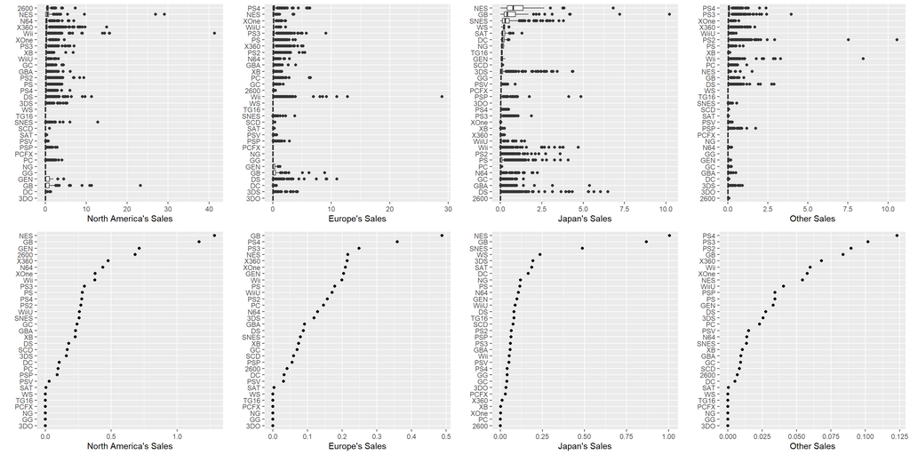

```r
sales_by_mean <-
video_game_data %>%
  group_by(Platform) %>%
  mutate(mean_NA_Sales = mean(NA_Sales),
         mean_EU_Sales = mean(EU_Sales),
         mean_JP_Sales = mean(JP_Sales),
         mean_Other_Sales = mean(Other_Sales)) #%>%
  #arrange(desc(mean_NA_sales))

#arranged_by_NA <-
 # sales_by_mean %>%
  #group_by(Platform) %>%
  #arrange(desc(mean_NA_Sales))

#arranged_by_EU <-
#  sales_by_mean %>%
#  arrange(desc(mean_EU_Sales))

#arranged_by_JP <-
#  sales_by_mean %>%
#  arrange(desc(mean_JP_Sales))

#arranged_by_Other <-
#  sales_by_mean %>%
#  arrange(desc(mean_Other_Sales))

plot1a <- ggplot(sales_by_mean, mapping = aes(x = reorder(Platform, mean_NA_Sales, FUN = median), y = mean_NA_Sales)) +
  geom_point() +
  ylab("North America's Sales") +
  xlab("") +
  coord_flip()

plot2a <- ggplot(sales_by_mean, mapping = aes(x = reorder(Platform, mean_EU_Sales, FUN = median), y = mean_EU_Sales)) +
  geom_point() +
  ylab("Europe's Sales") +
  xlab("") +
  coord_flip()

plot3a <- ggplot(sales_by_mean, mapping = aes(x = reorder(Platform, mean_JP_Sales, FUN = median), y = mean_JP_Sales)) +
  geom_point() +
  ylab("Japan's Sales") +
  xlab("") +
  coord_flip()

plot4a <- ggplot(sales_by_mean, mapping = aes(x = reorder(Platform, mean_Other_Sales, FUN = median), y = mean_Other_Sales)) +
  geom_point() +
  ylab("Other Sales") +
  xlab("") +
  coord_flip()

grid.arrange(plot1, plot2, plot3, plot4, plot1a, plot2a, plot3a, plot4a, ncol = 4)
```

When comparing the data of average sales, in north America, the number 1 platform is NES as well as Japan. But number 4 in Europe, and number 8 in other regions. In Europe the GB platform is number 1 whereas in North America and Japan it’s number 2, and number 4 in Other regions. In other regions, the PS4 is number one, number 11 in north America, number 2 in Europe, and number 22 in Japan.

# Question 2

```r
sales_by_mean %>%
  arrange(NA_Sales)
```

```
## # A tibble: 16,717 x 20
## # Groups:   Platform [31]
##    Name  Platform Year_of_Release Genre Publisher NA_Sales EU_Sales JP_Sales
##    <chr> <chr>    <chr>           <chr> <chr>        <dbl>    <dbl>    <dbl>
##  1 Mons~ PSP      2010            Role~ Capcom           0     0        4.87
##  2 Frie~ DS       2009            Misc  Nintendo         0     0        3.67
##  3 Mons~ 3DS      2013            Role~ Capcom           0     0        3.44
##  4 Engl~ DS       2006            Misc  Nintendo         0     0.99     2.32
##  5 Drag~ SNES     1995            Role~ Enix Cor~        0     0        3.19
##  6 Drag~ SNES     1992            Role~ Enix Cor~        0     0        2.78
##  7 Yoka~ 3DS      2014            Role~ Level 5          0     0        2.68
##  8 Supe~ NES      1986            Plat~ Nintendo         0     0        2.65
##  9 Fina~ SNES     1992            Role~ SquareSo~        0     0        2.43
## 10 Drag~ GB       1998            Role~ Eidos In~        0     0        2.34
## # ... with 16,707 more rows, and 12 more variables: Other_Sales <dbl>,
## #   Global_Sales <dbl>, Critic_Score <dbl>, Critic_Count <dbl>,
## #   User_Score <dbl>, User_Count <dbl>, Developer <chr>, Rating <chr>,
## #   mean_NA_Sales <dbl>, mean_EU_Sales <dbl>, mean_JP_Sales <dbl>,
## #   mean_Other_Sales <dbl>
```

```r
sales_by_mean %>%
  arrange(EU_Sales)
```

```
## # A tibble: 16,717 x 20
## # Groups:   Platform [31]
##    Name  Platform Year_of_Release Genre Publisher NA_Sales EU_Sales JP_Sales
##    <chr> <chr>    <chr>           <chr> <chr>        <dbl>    <dbl>    <dbl>
##  1 Fina~ PS2      2006            Role~ Square E~     1.88        0     2.33
##  2 Mons~ PSP      2010            Role~ Capcom        0           0     4.87
##  3 Meta~ PS2      2004            Acti~ Konami D~     1.46        0     0.83
##  4 Half~ PC       1997            Shoo~ Vivendi ~     4.03        0     0.09
##  5 Drag~ NES      1988            Role~ Enix Cor~     0.1         0     3.77
##  6 Frie~ DS       2009            Misc  Nintendo      0           0     3.67
##  7 Pro ~ PS2      2007            Spor~ Konami D~     0.05        0     0.64
##  8 Mons~ 3DS      2013            Role~ Capcom        0           0     3.44
##  9 Fina~ SNES     1994            Role~ SquareSo~     0.86        0     2.55
## 10 Yoka~ 3DS      2014            Role~ Nintendo      0.09        0     3.18
## # ... with 16,707 more rows, and 12 more variables: Other_Sales <dbl>,
## #   Global_Sales <dbl>, Critic_Score <dbl>, Critic_Count <dbl>,
## #   User_Score <dbl>, User_Count <dbl>, Developer <chr>, Rating <chr>,
## #   mean_NA_Sales <dbl>, mean_EU_Sales <dbl>, mean_JP_Sales <dbl>,
## #   mean_Other_Sales <dbl>
```

```r
sales_by_mean %>%
  arrange(JP_Sales)
```

```
## # A tibble: 16,717 x 20
## # Groups:   Platform [31]
##    Name  Platform Year_of_Release Genre Publisher NA_Sales EU_Sales JP_Sales
##    <chr> <chr>    <chr>           <chr> <chr>        <dbl>    <dbl>    <dbl>
##  1 Just~ Wii      2011            Misc  Ubisoft       5.95     3.11        0
##  2 The ~ PC       2009            Simu~ Electron~     0.99     6.42        0
##  3 Pac-~ 2600     1982            Puzz~ Atari         7.28     0.45        0
##  4 Call~ X360     2008            Shoo~ Activisi~     4.81     1.88        0
##  5 Just~ Wii      2009            Misc  Ubisoft       3.48     2.99        0
##  6 Just~ Wii      2012            Misc  Ubisoft       4.05     2.16        0
##  7 Zumb~ Wii      2010            Spor~ 505 Games     3.45     2.59        0
##  8 Worl~ PC       2004            Role~ Activisi~     0.08     6.21        0
##  9 LEGO~ Wii      2007            Acti~ LucasArts     3.57     1.55        0
## 10 Gran~ XOne     2014            Acti~ Take-Two~     2.81     2.19        0
## # ... with 16,707 more rows, and 12 more variables: Other_Sales <dbl>,
## #   Global_Sales <dbl>, Critic_Score <dbl>, Critic_Count <dbl>,
## #   User_Score <dbl>, User_Count <dbl>, Developer <chr>, Rating <chr>,
## #   mean_NA_Sales <dbl>, mean_EU_Sales <dbl>, mean_JP_Sales <dbl>,
## #   mean_Other_Sales <dbl>
```

```r
sales_by_mean %>%
  arrange(Other_Sales)
```

```
## # A tibble: 16,717 x 20
## # Groups:   Platform [31]
##    Name  Platform Year_of_Release Genre Publisher NA_Sales EU_Sales JP_Sales
##    <chr> <chr>    <chr>           <chr> <chr>        <dbl>    <dbl>    <dbl>
##  1 Worl~ PC       2004            Role~ Activisi~     0.08     6.21     0
##  2 Mons~ PSP      2010            Role~ Capcom        0        0        4.87
##  3 Half~ PC       1997            Shoo~ Vivendi ~     4.03     0        0.09
##  4 Worl~ PC       2007            Role~ Activisi~     2.57     1.52     0
##  5 Drag~ NES      1988            Role~ Enix Cor~     0.1      0        3.77
##  6 Frie~ DS       2009            Misc  Nintendo      0        0        3.67
##  7 Mons~ 3DS      2013            Role~ Capcom        0        0        3.44
##  8 Drag~ SNES     1995            Role~ Enix Cor~     0        0        3.19
##  9 Myst  PC       1994            Adve~ Red Orb       0.02     2.79     0
## 10 Yoka~ 3DS      2014            Role~ Level 5       0        0        2.68
## # ... with 16,707 more rows, and 12 more variables: Other_Sales <dbl>,
## #   Global_Sales <dbl>, Critic_Score <dbl>, Critic_Count <dbl>,
## #   User_Score <dbl>, User_Count <dbl>, Developer <chr>, Rating <chr>,
## #   mean_NA_Sales <dbl>, mean_EU_Sales <dbl>, mean_JP_Sales <dbl>,
## #   mean_Other_Sales <dbl>
```

# Question 2 part A

```r
cleaned_scores <-
  video_game_data %>%
  filter(User_Score != "tbd", !is.na(User_Score), !is.na(Critic_Score))

cleaned_scores$Critic_Score <- # make critic score on the same scale as user score
  cleaned_scores$Critic_Score/10

cleaned_scores %>%
  arrange(desc(Critic_Score))
```

```
## # A tibble: 7,017 x 16
##    Name  Platform Year_of_Release Genre Publisher NA_Sales EU_Sales JP_Sales
##    <chr> <chr>    <chr>           <chr> <chr>        <dbl>    <dbl>    <dbl>
##  1 Gran~ X360     2008            Acti~ Take-Two~     6.76     3.07     0.14
##  2 Gran~ PS3      2008            Acti~ Take-Two~     4.76     3.69     0.44
##  3 Tony~ PS       2000            Spor~ Activisi~     3.05     1.41     0.02
##  4 Soul~ DC       1999            Figh~ Namco Ba~     0        0        0.34
##  5 Gran~ PS3      2013            Acti~ Take-Two~     7.02     9.09     0.98
##  6 Gran~ X360     2013            Acti~ Take-Two~     9.66     5.14     0.06
##  7 Gran~ PS2      2001            Acti~ Take-Two~     6.99     4.51     0.3
##  8 Gran~ PS4      2014            Acti~ Take-Two~     3.96     6.31     0.38
##  9 Supe~ Wii      2007            Plat~ Nintendo      6.06     3.35     1.2
## 10 Supe~ Wii      2010            Plat~ Nintendo      3.56     2.35     0.98
## # ... with 7,007 more rows, and 8 more variables: Other_Sales <dbl>,
## #   Global_Sales <dbl>, Critic_Score <dbl>, Critic_Count <dbl>,
## #   User_Score <dbl>, User_Count <dbl>, Developer <chr>, Rating <chr>
```

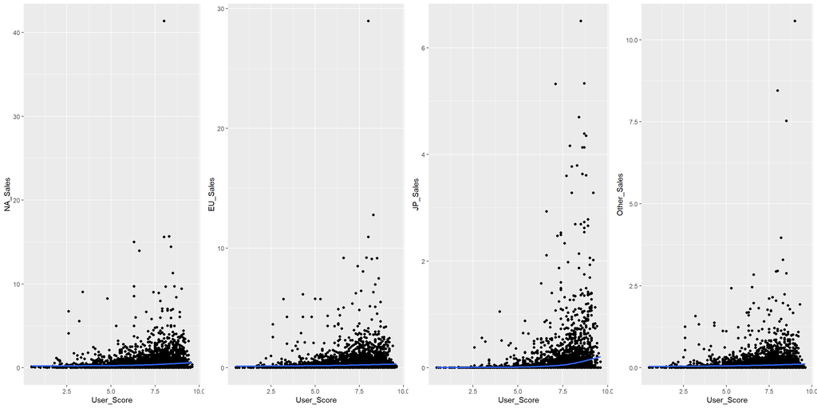

```r
plota<- ggplot(cleaned_scores) +
  geom_point(mapping = aes(x = User_Score, y = NA_Sales)) +
  geom_smooth(mapping = aes(x = User_Score, y = NA_Sales), se = F)

plotb <- ggplot(cleaned_scores) +
  geom_point(mapping = aes(x = User_Score, y = EU_Sales)) +
  geom_smooth(mapping = aes(x = User_Score, y = EU_Sales), se = F)

plotc <- ggplot(cleaned_scores) +
  geom_point(mapping = aes(x = User_Score, y = JP_Sales)) +
  geom_smooth(mapping = aes(x = User_Score, y = JP_Sales), se = F)

plotd <- ggplot(cleaned_scores) +
  geom_point(mapping = aes(x = User_Score, y = Other_Sales)) +
  geom_smooth(mapping = aes(x = User_Score, y = Other_Sales), se = F)

grid.arrange(plota, plotb, plotc, plotd, ncol = 4)
```

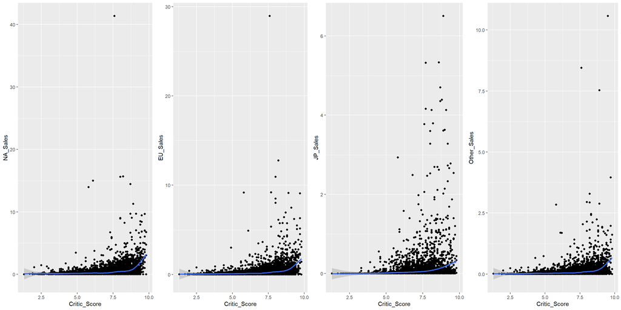

```r
plota1<- ggplot(cleaned_scores) +
  geom_point(mapping = aes(x = Critic_Score, y = NA_Sales)) +
  geom_smooth(mapping = aes(x = Critic_Score, y = NA_Sales))

plotb1<- ggplot(cleaned_scores) +
  geom_point(mapping = aes(x = Critic_Score, y = EU_Sales)) +
  geom_smooth(mapping = aes(x = Critic_Score, y = EU_Sales))

plotc1<- ggplot(cleaned_scores) +
  geom_point(mapping = aes(x = Critic_Score, y = JP_Sales)) +
  geom_smooth(mapping = aes(x = Critic_Score, y = JP_Sales))

plotd1<- ggplot(cleaned_scores) +
  geom_point(mapping = aes(x = Critic_Score, y = Other_Sales)) +
  geom_smooth(mapping = aes(x = Critic_Score, y = Other_Sales))

grid.arrange(plota1, plotb1, plotc1, plotd1, ncol = 4)
```

# Question 2b

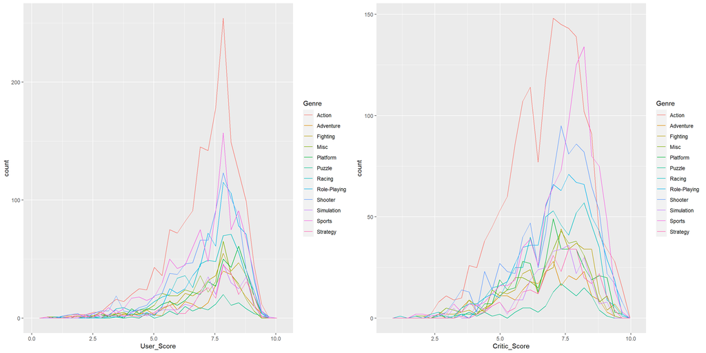

```r
# Did this by genre instead of each specific game

grouped_by_genre <-
  cleaned_scores %>%
  group_by(Genre)

plotaa <- ggplot( data = grouped_by_genre) +
  geom_freqpoly(mapping = aes(x = User_Score, color = Genre))

plotab <- ggplot( data = grouped_by_genre) +
  geom_freqpoly(mapping = aes(x = Critic_Score, color = Genre))

grid.arrange(plotaa, plotab, ncol = 2)
```